# ACS

### ACS Data Analysis

Jay Urbain, PhD

7/12/2017

2015 Participant Use Data File (PUF) available for download on the *American College of Surgeons National Surgical Quality Improvement Program* (ACS NSQIP) website ( www.facs.org/quality-programs/acs-nsqip ).

Contains 273 HIPAA compliant variables on 885,502 cases submitted from 603 sites in 2015.

#### Introduction:

*Data Collection Background and Data Quality*

The ACS NSQIP collects data on over 150 variables, including preoperative risk factors, intraoperative variables, and 30-day postoperative mortality and morbidity outcomes for patients undergoing major surgical procedures in both the inpatient and outpatient setting. A site’s trained and certified Surgical Clinical Reviewer (SCR) captures these data using a variety of methods including medical chart abstraction.

#### Results Summary

**This is just a placeholder - this work has not been completed**

We evaluate Logistic Regression (LR), Support Vector Machines (SVM), Decision Trees (DT), and recursive feature elimination for identifying the most predictive features in the data set.

#### Legend

Please see the[ACS NSQIP 2015 PUF USER GUIDE | OCTOBER 2016 (https://www.facs.org/~/media/files/quality%20programs/nsqip/nsqip_puf_user_guide_2015.ashx)

Here are the measured features:

PUFYEAR,CASEID,SEX,RACE_NEW,ETHNICITY_HISPANIC,PRNCPTX,CPT,WORKRVU,INOUT,TRANST,AGE,ADMYR, OPERYR,DISCHDEST,ANESTHES,SURGSPEC,ELECTSURG,HEIGHT,WEIGHT,DIABETES,SMOKE,DYSPNEA,FNSTATUS2, VENTILAT,HXCOPD,ASCITES,HXCHF,HYPERMED,RENAFAIL,DIALYSIS,DISCANCR,WNDINF,STEROID,WTLOSS,BLEEDIS, TRANSFUS,PRSEPIS,DPRNA,DPRBUN,DPRCREAT,DPRALBUM,DPRBILI,DPRSGOT,DPRALKPH,DPRWBC,DPRHCT,DPRPLATE, DPRPTT,DPRPT,DPRINR,PRSODM,PRBUN,PRCREAT,PRALBUM,PRBILI,PRSGOT,PRALKPH,PRWBC,PRHCT,PRPLATE,PRPTT, PRINR,PRPT,OTHERPROC1,OTHERCPT1,OTHERWRVU1,OTHERPROC2,OTHERCPT2,OTHERWRVU2,OTHERPROC3,OTHERCPT3, OTHERWRVU3,OTHERPROC4,OTHERCPT4,OTHERWRVU4,OTHERPROC5,OTHERCPT5,OTHERWRVU5,OTHERPROC6,OTHERCPT6, OTHERWRVU6,OTHERPROC7,OTHERCPT7,OTHERWRVU7,OTHERPROC8,OTHERCPT8,OTHERWRVU8,OTHERPROC9,OTHERCPT9, OTHERWRVU9,OTHERPROC10,OTHERCPT10,OTHERWRVU10,CONCURR1,CONCPT1,CONWRVU1,CONCURR2,CONCPT2,CONWRVU2, CONCURR3,CONCPT3,CONWRVU3,CONCURR4,CONCPT4,CONWRVU4,CONCURR5,CONCPT5,CONWRVU5,CONCURR6,CONCPT6, CONWRVU6,CONCURR7,CONCPT7,CONWRVU7,CONCURR8,CONCPT8,CONWRVU8,CONCURR9,CONCPT9,CONWRVU9,CONCURR10, CONCPT10,CONWRVU10,EMERGNCY,WNDCLAS,ASACLAS,MORTPROB,MORBPROB,OPTIME,HDISDT,YRDEATH,TOTHLOS,ADMQTR, HTOODAY,NSUPINFEC,SUPINFEC,SSSIPATOS,DSUPINFEC,NWNDINFD,WNDINFD,DSSIPATOS,DWNDINFD,NORGSPCSSI, ORGSPCSSI,OSSIPATOS,DORGSPCSSI,NDEHIS,DEHIS,DDEHIS,NOUPNEUMO,OUPNEUMO,PNAPATOS,DOUPNEUMO,NREINTUB, REINTUB,DREINTUB,NPULEMBOL,PULEMBOL,DPULEMBOL,NFAILWEAN,FAILWEAN,VENTPATOS,DFAILWEAN,NRENAINSF, RENAINSF,DRENAINSF,NOPRENAFL,OPRENAFL,DOPRENAFL,NURNINFEC,URNINFEC,UTIPATOS,DURNINFEC,NCNSCVA, CNSCVA,DCNSCVA,NCDARREST,CDARREST,DCDARREST,NCDMI,CDMI,DCDMI,NOTHBLEED,OTHBLEED,DOTHBLEED,NOTHDVT, OTHDVT,DOTHDVT,NOTHSYSEP,OTHSYSEP,SEPSISPATOS,DOTHSYSEP,NOTHSESHOCK,OTHSESHOCK,SEPSHOCKPATOS, DOTHSESHOCK,PODIAG,PODIAGTX,PODIAG10,PODIAGTX10,RETURNOR,DOPERTOD,DOPTODIS,STILLINHOSP,REOPERATION1, RETOR1PODAYS,REOPORCPT1,RETOR1RELATED,REOPOR1ICD91,REOPOR1ICD101,REOPERATION2,RETOR2PODAYS,REOPOR2CPT1, RETOR2RELATED,REOPOR2ICD91,REOPOR2ICD101,REOPERATION3,READMISSION1,READMPODAYS1,UNPLANNEDREADMISSION1, READMRELATED1,READMSUSPREASON1,READMUNRELSUSP1,READMRELICD91,READMRELICD101,READMUNRELICD91,READMUNRELICD101, READMISSION2,READMPODAYS2,UNPLANNEDREADMISSION2,READMRELATED2,READMSUSPREASON2,READMUNRELSUSP2,READMRELICD92, READMRELICD102,READMUNRELICD92,READMUNRELICD102,READMISSION3,READMPODAYS3,UNPLANNEDREADMISSION3, READMRELATED3,READMSUSPREASON3,READMUNRELSUSP3,READMRELICD93,READMRELICD103,READMUNRELICD93,READMUNRELICD103, READMISSION4,READMPODAYS4,UNPLANNEDREADMISSION4,READMRELATED4,READMSUSPREASON4,READMUNRELSUSP4,READMRELICD94, READMRELICD104,READMUNRELICD94,READMUNRELICD104,READMISSION5,READMPODAYS5,UNPLANNEDREADMISSION5,READMRELATED5, READMSUSPREASON5,READMUNRELSUSP5,READMRELICD95,READMRELICD105,READMUNRELICD95,READMUNRELICD105,WOUND_CLOSURE, PODIAG_OTHER,PODIAG_OTHER10,ANESTHES_OTHER,OTHCDIFF,NOTHCDIFF,DOTHCDIFF

#### Load the data

```python
import pandas as pd
import numpy as np
import matplotlib as plt
%matplotlib inline

import warnings
warnings.filterwarnings('ignore')

# Read dataset into a Pandas dataframe
df = pd.read_csv("data/acs_nsqip_puf15_v2.csv")
# Dimensions
df.shape
```

```
(885502, 274)
```

#### Reveiw the data

```python
import warnings
warnings.filterwarnings('ignore')

print(df.columns)

# show column distributions
# print(df.describe())
```

```
Index(['PUFYEAR', 'CASEID', 'SEX', 'RACE_NEW', 'ETHNICITY_HISPANIC',
       'PRNCPTX', 'CPT', 'WORKRVU', 'INOUT', 'TRANST',
       ...
       'READMRELICD105', 'READMUNRELICD95', 'READMUNRELICD105',
       'WOUND_CLOSURE', 'PODIAG_OTHER', 'PODIAG_OTHER10', 'ANESTHES_OTHER',
       'OTHCDIFF', 'NOTHCDIFF', 'DOTHCDIFF'],
      dtype='object', length=274)
```

```python
# dislay
df.ix[0:10, 0:20]
```

|  | PUFYEAR | CASEID | SEX | RACE_NEW | ETHNICITY_HISPANIC | PRNCPTX | CPT | WORKRVU | INOUT | TRANST | AGE | ADMYR | OPERYR | DISCHDEST | ANESTHES | SURGSPEC | ELECTSURG | HEIGHT | WEIGHT | DIABETES |
| --- | --- | --- | --- | --- | --- | --- | --- | --- | --- | --- | --- | --- | --- | --- | --- | --- | --- | --- | --- | --- |
| 0 | 2015 | 3873447 | male | White | N | LAPAROSCOPY SURG CHOLECYSTECTOMY | 47562 | 10.47 | Outpatient | Not transferred (admitted from home) | 36 | 2015 | 2015 | Home | General | General Surgery | Yes | 70 | 157 | NO |
| 1 | 2015 | 3873448 | female | White | N | DEBRIDEMENT MUSCLE & FASCIA 20 SQ CM/< | 11043 | 2.70 | Inpatient | Not transferred (admitted from home) | 33 | 2015 | 2015 | Rehab | General | General Surgery | No | 63 | 150 | INSULIN |
| 2 | 2015 | 3873449 | female | White | N | EMBLC/THRMBC FEMORAL POPLITEAL AORTO-ILIAC ART | 34201 | 19.48 | Inpatient | Outside emergency department | 63 | 2015 | 2015 | Rehab | General | Vascular | No | 62 | 220 | NO |
| 3 | 2015 | 3873450 | female | White | N | LAPAROSCOPY NEPHRECTOMY W/PARTIAL URETERECT | 50546 | 21.87 | Inpatient | Not transferred (admitted from home) | 38 | 2015 | 2015 | Home | General | Urology | Yes | 62 | 212 | NO |
| 4 | 2015 | 3873470 | female | White | N | EXC RCT PROCIDENTIA W/ANAST PERINEAL APPROACH | 45130 | 18.50 | Inpatient | Not transferred (admitted from home) | 72 | 2015 | 2015 | Home | General | General Surgery | Yes | 62 | 255 | NON-INSULIN |
| 5 | 2015 | 3873471 | male | White | N | MUSC MYOCUTANEOUS/FASCIOCUTANEOUS FLAP LXTR | 15738 | 19.04 | Outpatient | Not transferred (admitted from home) | 31 | 2015 | 2015 | Home | General | Plastics | Yes | 69 | 249 | NO |
| 6 | 2015 | 3873472 | male | White | N | REVSC OPN/PRQ FEM/POP W/STNT/ANGIOP SM VSL | 37226 | 10.49 | Outpatient | Not transferred (admitted from home) | 65 | 2015 | 2015 | Home | MAC/IV Sedation | Vascular | Yes | 68 | 183 | INSULIN |
| 7 | 2015 | 3873473 | male | White | N | MUSC MYOCUTANEOUS/FASCIOCUTANEOUS FLAP HEAD&NC | 15732 | 16.38 | Outpatient | Not transferred (admitted from home) | 63 | 2015 | 2015 | Home | General | Otolaryngology (ENT) | Yes | 74 | 218 | NO |
| 8 | 2015 | 3873435 | female | White | N | LAPAROSCOPY SURG CHOLECYSTECTOMY | 47562 | 10.47 | Outpatient | Not transferred (admitted from home) | 87 | 2015 | 2015 | Home | General | General Surgery | Yes | 61 | 145 | NO |
| 9 | 2015 | 3873436 | female | White | N | LAPAROSCOPY SURG CHOLECYSTECTOMY | 47562 | 10.47 | Outpatient | Not transferred (admitted from home) | 40 | 2015 | 2015 | Home | General | General Surgery | Yes | 63 | 219 | NON-INSULIN |
| 10 | 2015 | 3873437 | male | White | N | GSTRCT TOT W/ROUX-EN-Y RCNSTJ | 43621 | 39.53 | Inpatient | Not transferred (admitted from home) | 58 | 2015 | 2015 | Home | General | General Surgery | Yes | 69 | 223 | NON-INSULIN |

```python
# dislay
df.ix[0:10, 20:40]
```

|  | SMOKE | DYSPNEA | FNSTATUS2 | VENTILAT | HXCOPD | ASCITES | HXCHF | HYPERMED | RENAFAIL | DIALYSIS | DISCANCR | WNDINF | STEROID | WTLOSS | BLEEDIS | TRANSFUS | PRSEPIS | DPRNA | DPRBUN | DPRCREAT |
| --- | --- | --- | --- | --- | --- | --- | --- | --- | --- | --- | --- | --- | --- | --- | --- | --- | --- | --- | --- | --- |
| 0 | Yes | No | Independent | No | No | No | No | Yes | No | No | No | No | No | No | No | No | None | -99 | -99 | -99 |
| 1 | Yes | No | Independent | No | No | No | No | No | No | No | No | Yes | No | No | No | No | Sepsis | 0 | 0 | 0 |
| 2 | No | No | Partially Dependent | No | No | No | No | Yes | No | No | No | No | No | No | Yes | No | SIRS | 0 | 0 | 0 |
| 3 | No | No | Independent | No | No | No | No | No | No | No | No | No | No | No | No | No | None | 5 | 5 | 5 |
| 4 | No | No | Independent | No | No | No | No | Yes | No | No | No | No | Yes | No | No | No | None | 14 | 14 | 14 |
| 5 | Yes | No | Independent | No | No | No | No | Yes | No | No | No | Yes | No | No | No | No | None | -99 | -99 | -99 |
| 6 | No | MODERATE EXERTION | Independent | No | Yes | No | No | Yes | No | No | No | No | No | No | No | No | None | 9 | 9 | 9 |
| 7 | No | No | Independent | No | No | No | No | No | No | No | No | No | No | No | No | No | None | -99 | -99 | -99 |
| 8 | No | No | Independent | No | No | No | No | Yes | No | No | No | No | No | No | No | No | None | -99 | -99 | -99 |
| 9 | No | No | Independent | No | No | No | No | Yes | No | No | No | No | No | No | No | No | None | 0 | 0 | 0 |
| 10 | No | No | Independent | No | No | No | No | Yes | No | No | Yes | No | No | Yes | No | No | None | 34 | 34 | 34 |

```python
# dislay
df.ix[0:10, 40:60]
```

|  | DPRALBUM | DPRBILI | DPRSGOT | DPRALKPH | DPRWBC | DPRHCT | DPRPLATE | DPRPTT | DPRPT | DPRINR | PRSODM | PRBUN | PRCREAT | PRALBUM | PRBILI | PRSGOT | PRALKPH | PRWBC | PRHCT | PRPLATE |
| --- | --- | --- | --- | --- | --- | --- | --- | --- | --- | --- | --- | --- | --- | --- | --- | --- | --- | --- | --- | --- |
| 0 | -99 | -99 | -99 | -99 | -99 | -99 | -99 | -99 | -99 | -99 | -99.0 | -99.0 | -99.00 | -99.0 | -99.0 | -99.0 | -99.0 | -99.0 | -99.0 | -99.0 |
| 1 | 0 | 0 | 0 | 0 | 0 | 0 | 0 | 0 | -99 | 0 | 135.0 | 50.0 | 1.44 | 1.7 | 0.4 | 13.0 | 252.0 | 33.9 | 31.6 | 527.0 |
| 2 | -99 | -99 | -99 | -99 | 0 | 0 | 0 | 0 | -99 | 0 | 142.0 | 11.0 | 0.73 | -99.0 | -99.0 | -99.0 | -99.0 | 29.4 | 35.4 | 645.0 |
| 3 | -99 | -99 | -99 | -99 | 5 | 5 | 5 | -99 | -99 | -99 | 140.0 | 15.0 | 0.93 | -99.0 | -99.0 | -99.0 | -99.0 | 8.1 | 40.0 | 266.0 |
| 4 | 14 | 14 | 14 | 14 | 14 | 14 | 14 | -99 | -99 | -99 | 132.0 | 12.0 | 1.00 | 3.1 | 0.4 | 36.0 | 56.0 | 8.0 | 33.8 | 253.0 |
| 5 | -99 | -99 | -99 | -99 | -99 | -99 | -99 | -99 | -99 | -99 | -99.0 | -99.0 | -99.00 | -99.0 | -99.0 | -99.0 | -99.0 | -99.0 | -99.0 | -99.0 |
| 6 | -99 | -99 | -99 | -99 | 9 | 9 | 9 | -99 | -99 | 0 | 139.0 | 11.0 | 0.88 | -99.0 | -99.0 | -99.0 | -99.0 | 13.9 | 47.2 | 151.0 |
| 7 | -99 | -99 | -99 | -99 | -99 | -99 | -99 | -99 | -99 | -99 | -99.0 | -99.0 | -99.00 | -99.0 | -99.0 | -99.0 | -99.0 | -99.0 | -99.0 | -99.0 |
| 8 | -99 | -99 | -99 | -99 | -99 | -99 | -99 | -99 | -99 | -99 | -99.0 | -99.0 | -99.00 | -99.0 | -99.0 | -99.0 | -99.0 | -99.0 | -99.0 | -99.0 |
| 9 | -99 | -99 | -99 | -99 | -99 | -99 | -99 | -99 | -99 | -99 | 139.0 | 14.0 | 0.78 | -99.0 | -99.0 | -99.0 | -99.0 | -99.0 | -99.0 | -99.0 |
| 10 | 34 | 34 | 34 | 34 | 34 | 34 | 34 | -99 | -99 | -99 | 141.0 | 10.0 | 1.02 | 3.6 | 0.2 | 34.0 | 92.0 | 7.7 | 33.9 | 251.0 |

```python
# dislay
df.ix[0:10, 60:80]
```

|  | PRPTT | PRINR | PRPT | OTHERPROC1 | OTHERCPT1 | OTHERWRVU1 | OTHERPROC2 | OTHERCPT2 | OTHERWRVU2 | OTHERPROC3 | OTHERCPT3 | OTHERWRVU3 | OTHERPROC4 | OTHERCPT4 | OTHERWRVU4 | OTHERPROC5 | OTHERCPT5 | OTHERWRVU5 | OTHERPROC6 | OTHERCPT6 |
| --- | --- | --- | --- | --- | --- | --- | --- | --- | --- | --- | --- | --- | --- | --- | --- | --- | --- | --- | --- | --- |
| 0 | -99.0 | -99.0 | -99.0 | NaN | NaN | -99.00 | NaN | NaN | -99.00 | NaN | NaN | -99.0 | NaN | NaN | -99.0 | NaN | NaN | -99.0 | NaN | NaN |
| 1 | 20.0 | 1.0 | -99.0 | NaN | NaN | -99.00 | NaN | NaN | -99.00 | NaN | NaN | -99.0 | NaN | NaN | -99.0 | NaN | NaN | -99.0 | NaN | NaN |
| 2 | 20.0 | 0.9 | -99.0 | NaN | NaN | -99.00 | NaN | NaN | -99.00 | NaN | NaN | -99.0 | NaN | NaN | -99.0 | NaN | NaN | -99.0 | NaN | NaN |
| 3 | -99.0 | -99.0 | -99.0 | NaN | NaN | -99.00 | NaN | NaN | -99.00 | NaN | NaN | -99.0 | NaN | NaN | -99.0 | NaN | NaN | -99.0 | NaN | NaN |
| 4 | -99.0 | -99.0 | -99.0 | NaN | NaN | -99.00 | NaN | NaN | -99.00 | NaN | NaN | -99.0 | NaN | NaN | -99.0 | NaN | NaN | -99.0 | NaN | NaN |
| 5 | -99.0 | -99.0 | -99.0 | DEBRIDEMENT SUBCUTANEOUS TISSUE 20 SQ CM/< | 11042 | 1.01 | NaN | NaN | -99.00 | NaN | NaN | -99.0 | NaN | NaN | -99.0 | NaN | NaN | -99.0 | NaN | NaN |
| 6 | -99.0 | 1.2 | -99.0 | NaN | NaN | -99.00 | NaN | NaN | -99.00 | NaN | NaN | -99.0 | NaN | NaN | -99.0 | NaN | NaN | -99.0 | NaN | NaN |
| 7 | -99.0 | -99.0 | -99.0 | RHINOPLASTY PRIMARY W/MAJOR SEPTAL REPAIR | 30420 | 16.90 | NaN | NaN | -99.00 | NaN | NaN | -99.0 | NaN | NaN | -99.0 | NaN | NaN | -99.0 | NaN | NaN |
| 8 | -99.0 | -99.0 | -99.0 | NaN | NaN | -99.00 | NaN | NaN | -99.00 | NaN | NaN | -99.0 | NaN | NaN | -99.0 | NaN | NaN | -99.0 | NaN | NaN |
| 9 | -99.0 | -99.0 | -99.0 | NaN | NaN | -99.00 | NaN | NaN | -99.00 | NaN | NaN | -99.0 | NaN | NaN | -99.0 | NaN | NaN | -99.0 | NaN | NaN |
| 10 | -99.0 | -99.0 | -99.0 | TUBE/NEEDLE CATH JEJUNOSTOMY ANY METHOD | 44015 | 2.62 | ABDL LMPHADEC REG CELIAC GSTR PORTAL PRIPNCRTC | 38747 | 4.88 | NaN | NaN | -99.0 | NaN | NaN | -99.0 | NaN | NaN | -99.0 | NaN | NaN |

```python
# dislay
df.ix[0:20, 80:100]
```

|  | OTHERWRVU6 | OTHERPROC7 | OTHERCPT7 | OTHERWRVU7 | OTHERPROC8 | OTHERCPT8 | OTHERWRVU8 | OTHERPROC9 | OTHERCPT9 | OTHERWRVU9 | OTHERPROC10 | OTHERCPT10 | OTHERWRVU10 | CONCURR1 | CONCPT1 | CONWRVU1 | CONCURR2 | CONCPT2 | CONWRVU2 | CONCURR3 |
| --- | --- | --- | --- | --- | --- | --- | --- | --- | --- | --- | --- | --- | --- | --- | --- | --- | --- | --- | --- | --- |
| 0 | -99.0 | NaN | NaN | -99.0 | NaN | NaN | -99.0 | NaN | NaN | -99.0 | NaN | NaN | -99.0 | NaN | NaN | -99.00 | NaN | NaN | -99.00 | NaN |
| 1 | -99.0 | NaN | NaN | -99.0 | NaN | NaN | -99.0 | NaN | NaN | -99.0 | NaN | NaN | -99.0 | NaN | NaN | -99.00 | NaN | NaN | -99.00 | NaN |
| 2 | -99.0 | NaN | NaN | -99.0 | NaN | NaN | -99.0 | NaN | NaN | -99.0 | NaN | NaN | -99.0 | NaN | NaN | -99.00 | NaN | NaN | -99.00 | NaN |
| 3 | -99.0 | NaN | NaN | -99.0 | NaN | NaN | -99.0 | NaN | NaN | -99.0 | NaN | NaN | -99.0 | NaN | NaN | -99.00 | NaN | NaN | -99.00 | NaN |
| 4 | -99.0 | NaN | NaN | -99.0 | NaN | NaN | -99.0 | NaN | NaN | -99.0 | NaN | NaN | -99.0 | NaN | NaN | -99.00 | NaN | NaN | -99.00 | NaN |
| 5 | -99.0 | NaN | NaN | -99.0 | NaN | NaN | -99.0 | NaN | NaN | -99.0 | NaN | NaN | -99.0 | NaN | NaN | -99.00 | NaN | NaN | -99.00 | NaN |
| 6 | -99.0 | NaN | NaN | -99.0 | NaN | NaN | -99.0 | NaN | NaN | -99.0 | NaN | NaN | -99.0 | NaN | NaN | -99.00 | NaN | NaN | -99.00 | NaN |
| 7 | -99.0 | NaN | NaN | -99.0 | NaN | NaN | -99.0 | NaN | NaN | -99.0 | NaN | NaN | -99.0 | NaN | NaN | -99.00 | NaN | NaN | -99.00 | NaN |
| 8 | -99.0 | NaN | NaN | -99.0 | NaN | NaN | -99.0 | NaN | NaN | -99.0 | NaN | NaN | -99.0 | NaN | NaN | -99.00 | NaN | NaN | -99.00 | NaN |
| 9 | -99.0 | NaN | NaN | -99.0 | NaN | NaN | -99.0 | NaN | NaN | -99.0 | NaN | NaN | -99.0 | NaN | NaN | -99.00 | NaN | NaN | -99.00 | NaN |
| 10 | -99.0 | NaN | NaN | -99.0 | NaN | NaN | -99.0 | NaN | NaN | -99.0 | NaN | NaN | -99.0 | THORACOSCOPY W/EXC MEDIASTINAL CYST TUMOR/MASS | 32662 | 14.99 | THORCOSCPY W/MEDIASTINL & REGIONL LYMPHDENECTOMY | 32674 | 4.12 | NaN |
| 11 | -99.0 | NaN | NaN | -99.0 | NaN | NaN | -99.0 | NaN | NaN | -99.0 | NaN | NaN | -99.0 | NaN | NaN | -99.00 | NaN | NaN | -99.00 | NaN |
| 12 | -99.0 | NaN | NaN | -99.0 | NaN | NaN | -99.0 | NaN | NaN | -99.0 | NaN | NaN | -99.0 | NaN | NaN | -99.00 | NaN | NaN | -99.00 | NaN |
| 13 | -99.0 | NaN | NaN | -99.0 | NaN | NaN | -99.0 | NaN | NaN | -99.0 | NaN | NaN | -99.0 | NaN | NaN | -99.00 | NaN | NaN | -99.00 | NaN |
| 14 | -99.0 | NaN | NaN | -99.0 | NaN | NaN | -99.0 | NaN | NaN | -99.0 | NaN | NaN | -99.0 | NaN | NaN | -99.00 | NaN | NaN | -99.00 | NaN |
| 15 | -99.0 | NaN | NaN | -99.0 | NaN | NaN | -99.0 | NaN | NaN | -99.0 | NaN | NaN | -99.0 | NaN | NaN | -99.00 | NaN | NaN | -99.00 | NaN |
| 16 | -99.0 | NaN | NaN | -99.0 | NaN | NaN | -99.0 | NaN | NaN | -99.0 | NaN | NaN | -99.0 | NaN | NaN | -99.00 | NaN | NaN | -99.00 | NaN |
| 17 | -99.0 | NaN | NaN | -99.0 | NaN | NaN | -99.0 | NaN | NaN | -99.0 | NaN | NaN | -99.0 | NaN | NaN | -99.00 | NaN | NaN | -99.00 | NaN |
| 18 | -99.0 | NaN | NaN | -99.0 | NaN | NaN | -99.0 | NaN | NaN | -99.0 | NaN | NaN | -99.0 | NaN | NaN | -99.00 | NaN | NaN | -99.00 | NaN |
| 19 | -99.0 | NaN | NaN | -99.0 | NaN | NaN | -99.0 | NaN | NaN | -99.0 | NaN | NaN | -99.0 | NaN | NaN | -99.00 | NaN | NaN | -99.00 | NaN |
| 20 | -99.0 | NaN | NaN | -99.0 | NaN | NaN | -99.0 | NaN | NaN | -99.0 | NaN | NaN | -99.0 | NaN | NaN | -99.00 | NaN | NaN | -99.00 | NaN |

```python
# dislay
df.ix[0:10, 80:100]
```

|  | OTHERWRVU6 | OTHERPROC7 | OTHERCPT7 | OTHERWRVU7 | OTHERPROC8 | OTHERCPT8 | OTHERWRVU8 | OTHERPROC9 | OTHERCPT9 | OTHERWRVU9 | OTHERPROC10 | OTHERCPT10 | OTHERWRVU10 | CONCURR1 | CONCPT1 | CONWRVU1 | CONCURR2 | CONCPT2 | CONWRVU2 | CONCURR3 |
| --- | --- | --- | --- | --- | --- | --- | --- | --- | --- | --- | --- | --- | --- | --- | --- | --- | --- | --- | --- | --- |
| 0 | -99.0 | NaN | NaN | -99.0 | NaN | NaN | -99.0 | NaN | NaN | -99.0 | NaN | NaN | -99.0 | NaN | NaN | -99.00 | NaN | NaN | -99.00 | NaN |
| 1 | -99.0 | NaN | NaN | -99.0 | NaN | NaN | -99.0 | NaN | NaN | -99.0 | NaN | NaN | -99.0 | NaN | NaN | -99.00 | NaN | NaN | -99.00 | NaN |
| 2 | -99.0 | NaN | NaN | -99.0 | NaN | NaN | -99.0 | NaN | NaN | -99.0 | NaN | NaN | -99.0 | NaN | NaN | -99.00 | NaN | NaN | -99.00 | NaN |
| 3 | -99.0 | NaN | NaN | -99.0 | NaN | NaN | -99.0 | NaN | NaN | -99.0 | NaN | NaN | -99.0 | NaN | NaN | -99.00 | NaN | NaN | -99.00 | NaN |
| 4 | -99.0 | NaN | NaN | -99.0 | NaN | NaN | -99.0 | NaN | NaN | -99.0 | NaN | NaN | -99.0 | NaN | NaN | -99.00 | NaN | NaN | -99.00 | NaN |
| 5 | -99.0 | NaN | NaN | -99.0 | NaN | NaN | -99.0 | NaN | NaN | -99.0 | NaN | NaN | -99.0 | NaN | NaN | -99.00 | NaN | NaN | -99.00 | NaN |
| 6 | -99.0 | NaN | NaN | -99.0 | NaN | NaN | -99.0 | NaN | NaN | -99.0 | NaN | NaN | -99.0 | NaN | NaN | -99.00 | NaN | NaN | -99.00 | NaN |
| 7 | -99.0 | NaN | NaN | -99.0 | NaN | NaN | -99.0 | NaN | NaN | -99.0 | NaN | NaN | -99.0 | NaN | NaN | -99.00 | NaN | NaN | -99.00 | NaN |
| 8 | -99.0 | NaN | NaN | -99.0 | NaN | NaN | -99.0 | NaN | NaN | -99.0 | NaN | NaN | -99.0 | NaN | NaN | -99.00 | NaN | NaN | -99.00 | NaN |
| 9 | -99.0 | NaN | NaN | -99.0 | NaN | NaN | -99.0 | NaN | NaN | -99.0 | NaN | NaN | -99.0 | NaN | NaN | -99.00 | NaN | NaN | -99.00 | NaN |
| 10 | -99.0 | NaN | NaN | -99.0 | NaN | NaN | -99.0 | NaN | NaN | -99.0 | NaN | NaN | -99.0 | THORACOSCOPY W/EXC MEDIASTINAL CYST TUMOR/MASS | 32662 | 14.99 | THORCOSCPY W/MEDIASTINL & REGIONL LYMPHDENECTOMY | 32674 | 4.12 | NaN |

```python
# dislay
df.ix[0:10, 100:120]
```

|  | CONCPT3 | CONWRVU3 | CONCURR4 | CONCPT4 | CONWRVU4 | CONCURR5 | CONCPT5 | CONWRVU5 | CONCURR6 | CONCPT6 | CONWRVU6 | CONCURR7 | CONCPT7 | CONWRVU7 | CONCURR8 | CONCPT8 | CONWRVU8 | CONCURR9 | CONCPT9 | CONWRVU9 |
| --- | --- | --- | --- | --- | --- | --- | --- | --- | --- | --- | --- | --- | --- | --- | --- | --- | --- | --- | --- | --- |
| 0 | NaN | -99.0 | NaN | NaN | -99.0 | NaN | NaN | -99.0 | NaN | NaN | -99.0 | NaN | NaN | -99.0 | NaN | NaN | -99.0 | NaN | NaN | -99.0 |
| 1 | NaN | -99.0 | NaN | NaN | -99.0 | NaN | NaN | -99.0 | NaN | NaN | -99.0 | NaN | NaN | -99.0 | NaN | NaN | -99.0 | NaN | NaN | -99.0 |
| 2 | NaN | -99.0 | NaN | NaN | -99.0 | NaN | NaN | -99.0 | NaN | NaN | -99.0 | NaN | NaN | -99.0 | NaN | NaN | -99.0 | NaN | NaN | -99.0 |
| 3 | NaN | -99.0 | NaN | NaN | -99.0 | NaN | NaN | -99.0 | NaN | NaN | -99.0 | NaN | NaN | -99.0 | NaN | NaN | -99.0 | NaN | NaN | -99.0 |
| 4 | NaN | -99.0 | NaN | NaN | -99.0 | NaN | NaN | -99.0 | NaN | NaN | -99.0 | NaN | NaN | -99.0 | NaN | NaN | -99.0 | NaN | NaN | -99.0 |
| 5 | NaN | -99.0 | NaN | NaN | -99.0 | NaN | NaN | -99.0 | NaN | NaN | -99.0 | NaN | NaN | -99.0 | NaN | NaN | -99.0 | NaN | NaN | -99.0 |
| 6 | NaN | -99.0 | NaN | NaN | -99.0 | NaN | NaN | -99.0 | NaN | NaN | -99.0 | NaN | NaN | -99.0 | NaN | NaN | -99.0 | NaN | NaN | -99.0 |
| 7 | NaN | -99.0 | NaN | NaN | -99.0 | NaN | NaN | -99.0 | NaN | NaN | -99.0 | NaN | NaN | -99.0 | NaN | NaN | -99.0 | NaN | NaN | -99.0 |
| 8 | NaN | -99.0 | NaN | NaN | -99.0 | NaN | NaN | -99.0 | NaN | NaN | -99.0 | NaN | NaN | -99.0 | NaN | NaN | -99.0 | NaN | NaN | -99.0 |
| 9 | NaN | -99.0 | NaN | NaN | -99.0 | NaN | NaN | -99.0 | NaN | NaN | -99.0 | NaN | NaN | -99.0 | NaN | NaN | -99.0 | NaN | NaN | -99.0 |
| 10 | NaN | -99.0 | NaN | NaN | -99.0 | NaN | NaN | -99.0 | NaN | NaN | -99.0 | NaN | NaN | -99.0 | NaN | NaN | -99.0 | NaN | NaN | -99.0 |

```python
# dislay
df.ix[0:10, 120:140]
```

|  | CONCURR10 | CONCPT10 | CONWRVU10 | EMERGNCY | WNDCLAS | ASACLAS | MORTPROB | MORBPROB | OPTIME | HDISDT | YRDEATH | TOTHLOS | ADMQTR | HTOODAY | NSUPINFEC | SUPINFEC | SSSIPATOS | DSUPINFEC | NWNDINFD | WNDINFD |
| --- | --- | --- | --- | --- | --- | --- | --- | --- | --- | --- | --- | --- | --- | --- | --- | --- | --- | --- | --- | --- |
| 0 | NaN | NaN | -99.0 | No | 2-Clean/Contaminated | 3-Severe Disturb | 0.000361 | 0.016954 | 90 | 2015 | -99 | 0 | 1 | 0.0 | 0 | No Complication | No | -99 | 0 | No Complication |
| 1 | NaN | NaN | -99.0 | Yes | 4-Dirty/Infected | 4-Life Threat | 0.035697 | 0.241115 | 109 | 2015 | -99 | 29 | 1 | 0.0 | 0 | No Complication | No | -99 | 0 | No Complication |
| 2 | NaN | NaN | -99.0 | Yes | 1-Clean | 3-Severe Disturb | 0.060460 | 0.276297 | 133 | 2015 | -99 | 15 | 1 | 0.0 | 0 | No Complication | No | -99 | 0 | No Complication |
| 3 | NaN | NaN | -99.0 | No | 2-Clean/Contaminated | 2-Mild Disturb | 0.000296 | 0.040974 | 118 | 2015 | -99 | 3 | 1 | 0.0 | 0 | No Complication | No | -99 | 0 | No Complication |
| 4 | NaN | NaN | -99.0 | No | 2-Clean/Contaminated | 3-Severe Disturb | 0.007993 | 0.106420 | 94 | 2015 | -99 | 2 | 1 | 0.0 | 0 | No Complication | No | -99 | 0 | No Complication |
| 5 | NaN | NaN | -99.0 | No | 3-Contaminated | 2-Mild Disturb | 0.000141 | 0.067619 | 104 | 2015 | -99 | 1 | 1 | 0.0 | 0 | No Complication | No | -99 | 0 | No Complication |
| 6 | NaN | NaN | -99.0 | No | 1-Clean | 3-Severe Disturb | 0.004212 | 0.039158 | 89 | 2015 | -99 | 1 | 1 | 0.0 | 0 | No Complication | No | -99 | 0 | No Complication |
| 7 | NaN | NaN | -99.0 | No | 1-Clean | 2-Mild Disturb | 0.001002 | 0.036357 | 239 | 2015 | -99 | 0 | 1 | 0.0 | 0 | No Complication | No | -99 | 0 | No Complication |
| 8 | NaN | NaN | -99.0 | No | 2-Clean/Contaminated | 3-Severe Disturb | 0.002658 | 0.021693 | 42 | 2015 | -99 | 1 | 1 | 0.0 | 0 | No Complication | No | -99 | 0 | No Complication |
| 9 | NaN | NaN | -99.0 | No | 2-Clean/Contaminated | 3-Severe Disturb | 0.000329 | 0.019213 | 124 | 2015 | -99 | 0 | 1 | 0.0 | 0 | No Complication | No | -99 | 0 | No Complication |
| 10 | NaN | NaN | -99.0 | No | 2-Clean/Contaminated | 3-Severe Disturb | 0.029464 | 0.286880 | 470 | 2015 | -99 | 8 | 1 | 0.0 | 0 | No Complication | No | -99 | 0 | No Complication |

```python
# dislay
df.ix[0:10, 140:160]
```

|  | DSSIPATOS | DWNDINFD | NORGSPCSSI | ORGSPCSSI | OSSIPATOS | DORGSPCSSI | NDEHIS | DEHIS | DDEHIS | NOUPNEUMO | OUPNEUMO | PNAPATOS | DOUPNEUMO | NREINTUB | REINTUB | DREINTUB | NPULEMBOL | PULEMBOL | DPULEMBOL | NFAILWEAN |
| --- | --- | --- | --- | --- | --- | --- | --- | --- | --- | --- | --- | --- | --- | --- | --- | --- | --- | --- | --- | --- |
| 0 | No | -99 | 0 | No Complication | No | -99 | 0 | No Complication | -99 | 0 | No Complication | No | -99 | 0 | No Complication | -99.0 | 0 | No Complication | -99 | 0 |
| 1 | No | -99 | 0 | No Complication | No | -99 | 0 | No Complication | -99 | 0 | No Complication | No | -99 | 1 | Unplanned Intubation | 13.0 | 0 | No Complication | -99 | 1 |
| 2 | No | -99 | 0 | No Complication | No | -99 | 0 | No Complication | -99 | 0 | No Complication | No | -99 | 0 | No Complication | -99.0 | 0 | No Complication | -99 | 0 |
| 3 | No | -99 | 0 | No Complication | No | -99 | 0 | No Complication | -99 | 0 | No Complication | No | -99 | 0 | No Complication | -99.0 | 0 | No Complication | -99 | 0 |
| 4 | No | -99 | 0 | No Complication | No | -99 | 0 | No Complication | -99 | 0 | No Complication | No | -99 | 0 | No Complication | -99.0 | 0 | No Complication | -99 | 0 |
| 5 | No | -99 | 0 | No Complication | No | -99 | 0 | No Complication | -99 | 0 | No Complication | No | -99 | 0 | No Complication | -99.0 | 0 | No Complication | -99 | 0 |
| 6 | No | -99 | 0 | No Complication | No | -99 | 0 | No Complication | -99 | 0 | No Complication | No | -99 | 0 | No Complication | -99.0 | 0 | No Complication | -99 | 0 |
| 7 | No | -99 | 0 | No Complication | No | -99 | 0 | No Complication | -99 | 0 | No Complication | No | -99 | 0 | No Complication | -99.0 | 0 | No Complication | -99 | 0 |
| 8 | No | -99 | 0 | No Complication | No | -99 | 0 | No Complication | -99 | 0 | No Complication | No | -99 | 0 | No Complication | -99.0 | 0 | No Complication | -99 | 0 |
| 9 | No | -99 | 0 | No Complication | No | -99 | 0 | No Complication | -99 | 0 | No Complication | No | -99 | 0 | No Complication | -99.0 | 0 | No Complication | -99 | 0 |
| 10 | No | -99 | 0 | No Complication | No | -99 | 0 | No Complication | -99 | 0 | No Complication | No | -99 | 0 | No Complication | -99.0 | 0 | No Complication | -99 | 0 |

```python
# dislay
df.ix[0:10, 160:180]
```

|  | FAILWEAN | VENTPATOS | DFAILWEAN | NRENAINSF | RENAINSF | DRENAINSF | NOPRENAFL | OPRENAFL | DOPRENAFL | NURNINFEC | URNINFEC | UTIPATOS | DURNINFEC | NCNSCVA | CNSCVA | DCNSCVA | NCDARREST | CDARREST | DCDARREST | NCDMI |
| --- | --- | --- | --- | --- | --- | --- | --- | --- | --- | --- | --- | --- | --- | --- | --- | --- | --- | --- | --- | --- |
| 0 | No Complication | No | -99 | 0 | No Complication | -99 | 0 | No Complication | -99 | 0 | No Complication | No | -99 | 0 | No Complication | -99 | 0 | No Complication | -99 | 0 |
| 1 | On Ventilator greater than 48 Hours | No | 15 | 0 | No Complication | -99 | 0 | No Complication | -99 | 0 | No Complication | No | -99 | 0 | No Complication | -99 | 0 | No Complication | -99 | 0 |
| 2 | No Complication | No | -99 | 0 | No Complication | -99 | 0 | No Complication | -99 | 0 | No Complication | No | -99 | 0 | No Complication | -99 | 0 | No Complication | -99 | 0 |
| 3 | No Complication | No | -99 | 0 | No Complication | -99 | 0 | No Complication | -99 | 0 | No Complication | No | -99 | 0 | No Complication | -99 | 0 | No Complication | -99 | 0 |
| 4 | No Complication | No | -99 | 0 | No Complication | -99 | 0 | No Complication | -99 | 0 | No Complication | No | -99 | 0 | No Complication | -99 | 0 | No Complication | -99 | 0 |
| 5 | No Complication | No | -99 | 0 | No Complication | -99 | 0 | No Complication | -99 | 0 | No Complication | No | -99 | 0 | No Complication | -99 | 0 | No Complication | -99 | 0 |
| 6 | No Complication | No | -99 | 0 | No Complication | -99 | 0 | No Complication | -99 | 0 | No Complication | No | -99 | 0 | No Complication | -99 | 0 | No Complication | -99 | 0 |
| 7 | No Complication | No | -99 | 0 | No Complication | -99 | 0 | No Complication | -99 | 0 | No Complication | No | -99 | 0 | No Complication | -99 | 0 | No Complication | -99 | 0 |
| 8 | No Complication | No | -99 | 0 | No Complication | -99 | 0 | No Complication | -99 | 0 | No Complication | No | -99 | 0 | No Complication | -99 | 0 | No Complication | -99 | 0 |
| 9 | No Complication | No | -99 | 0 | No Complication | -99 | 0 | No Complication | -99 | 0 | No Complication | No | -99 | 0 | No Complication | -99 | 0 | No Complication | -99 | 0 |
| 10 | No Complication | No | -99 | 0 | No Complication | -99 | 0 | No Complication | -99 | 0 | No Complication | No | -99 | 0 | No Complication | -99 | 0 | No Complication | -99 | 0 |

```python
# dislay
df.ix[0:10, 180:200]
```

|  | CDMI | DCDMI | NOTHBLEED | OTHBLEED | DOTHBLEED | NOTHDVT | OTHDVT | DOTHDVT | NOTHSYSEP | OTHSYSEP | SEPSISPATOS | DOTHSYSEP | NOTHSESHOCK | OTHSESHOCK | SEPSHOCKPATOS | DOTHSESHOCK | PODIAG | PODIAGTX | PODIAG10 | PODIAGTX10 |
| --- | --- | --- | --- | --- | --- | --- | --- | --- | --- | --- | --- | --- | --- | --- | --- | --- | --- | --- | --- | --- |
| 0 | No Complication | -99 | 0 | No Complication | -99.0 | 0 | No Complication | -99 | 0 | No Complication | No | -99 | 0 | No Complication | No | -99 | 575.8 | OTHER SPECIFIED DISORDERS OF GALLBLADDER | NaN | NaN |
| 1 | No Complication | -99 | 1 | Transfusions/Intraop/Postop | 1.0 | 0 | No Complication | -99 | 1 | Sepsis | No | 1 | 1 | Septic Shock | Yes | 13 | 728.86 | NECROTIZING FASCIITIS | NaN | NaN |
| 2 | No Complication | -99 | 1 | Transfusions/Intraop/Postop | 1.0 | 0 | No Complication | -99 | 0 | No Complication | No | -99 | 0 | No Complication | No | -99 | 444.22 | ARTERIAL EMBOLISM AND THROMBOSIS OF LOWER EXTR... | NaN | NaN |
| 3 | No Complication | -99 | 0 | No Complication | -99.0 | 0 | No Complication | -99 | 0 | No Complication | No | -99 | 0 | No Complication | No | -99 | 593.9 | UNSPECIFIED DISORDER OF KIDNEY AND URETER | NaN | NaN |
| 4 | No Complication | -99 | 0 | No Complication | -99.0 | 0 | No Complication | -99 | 0 | No Complication | No | -99 | 0 | No Complication | No | -99 | 569.1 | RECTAL PROLAPSE | NaN | NaN |
| 5 | No Complication | -99 | 0 | No Complication | -99.0 | 0 | No Complication | -99 | 0 | No Complication | No | -99 | 0 | No Complication | No | -99 | 891.1 | OPEN WOUND OF KNEE LEG (EXCEPT THIGH) AND ANKL... | NaN | NaN |
| 6 | No Complication | -99 | 0 | No Complication | -99.0 | 0 | No Complication | -99 | 0 | No Complication | No | -99 | 0 | No Complication | No | -99 | 443.9 | PERIPHERAL VASCULAR DISEASE UNSPECIFIED | NaN | NaN |
| 7 | No Complication | -99 | 0 | No Complication | -99.0 | 0 | No Complication | -99 | 0 | No Complication | No | -99 | 0 | No Complication | No | -99 | 173.32 | SQUAMOUS CELL CARCINOMA OF SKIN OF OTHER AND U... | NaN | NaN |
| 8 | No Complication | -99 | 0 | No Complication | -99.0 | 0 | No Complication | -99 | 0 | No Complication | No | -99 | 0 | No Complication | No | -99 | 574.20 | CALCULUS OF GALLBLADDER WITHOUT CHOLECYSTITIS ... | NaN | NaN |
| 9 | No Complication | -99 | 0 | No Complication | -99.0 | 0 | No Complication | -99 | 0 | No Complication | No | -99 | 0 | No Complication | No | -99 | 575.8 | OTHER SPECIFIED DISORDERS OF GALLBLADDER | NaN | NaN |
| 10 | No Complication | -99 | 0 | No Complication | -99.0 | 0 | No Complication | -99 | 0 | No Complication | No | -99 | 0 | No Complication | No | -99 | 151.0 | MALIGNANT NEOPLASM OF CARDIA | NaN | NaN |

```python
# dislay
df.ix[0:10, 200:220]
```

|  | RETURNOR | DOPERTOD | DOPTODIS | STILLINHOSP | REOPERATION1 | RETOR1PODAYS | REOPORCPT1 | RETOR1RELATED | REOPOR1ICD91 | REOPOR1ICD101 | REOPERATION2 | RETOR2PODAYS | REOPOR2CPT1 | RETOR2RELATED | REOPOR2ICD91 | REOPOR2ICD101 | REOPERATION3 | READMISSION1 | READMPODAYS1 | UNPLANNEDREADMISSION1 |
| --- | --- | --- | --- | --- | --- | --- | --- | --- | --- | --- | --- | --- | --- | --- | --- | --- | --- | --- | --- | --- |
| 0 | No | -99 | 0 | No | No | -99 | NaN | NaN | NaN | NaN | NaN | -99 | NaN | NaN | NaN | NaN | NaN | No | -99 | NaN |
| 1 | No | -99 | 29 | No | No | -99 | NaN | NaN | NaN | NaN | NaN | -99 | NaN | NaN | NaN | NaN | NaN | No | -99 | NaN |
| 2 | No | -99 | 15 | No | No | -99 | NaN | NaN | NaN | NaN | NaN | -99 | NaN | NaN | NaN | NaN | NaN | No | -99 | NaN |
| 3 | No | -99 | 3 | No | No | -99 | NaN | NaN | NaN | NaN | NaN | -99 | NaN | NaN | NaN | NaN | NaN | No | -99 | NaN |
| 4 | No | -99 | 2 | No | No | -99 | NaN | NaN | NaN | NaN | NaN | -99 | NaN | NaN | NaN | NaN | NaN | No | -99 | NaN |
| 5 | No | -99 | 1 | No | No | -99 | NaN | NaN | NaN | NaN | NaN | -99 | NaN | NaN | NaN | NaN | NaN | No | -99 | NaN |
| 6 | No | -99 | 1 | No | No | -99 | NaN | NaN | NaN | NaN | NaN | -99 | NaN | NaN | NaN | NaN | NaN | No | -99 | NaN |
| 7 | No | -99 | 0 | No | No | -99 | NaN | NaN | NaN | NaN | NaN | -99 | NaN | NaN | NaN | NaN | NaN | No | -99 | NaN |
| 8 | No | -99 | 1 | No | No | -99 | NaN | NaN | NaN | NaN | NaN | -99 | NaN | NaN | NaN | NaN | NaN | No | -99 | NaN |
| 9 | No | -99 | 0 | No | No | -99 | NaN | NaN | NaN | NaN | NaN | -99 | NaN | NaN | NaN | NaN | NaN | No | -99 | NaN |
| 10 | No | -99 | 8 | No | No | -99 | NaN | NaN | NaN | NaN | NaN | -99 | NaN | NaN | NaN | NaN | NaN | Yes | 18 | Yes |

```python
# dislay
df.ix[0:10, 220:240]
```

|  | READMRELATED1 | READMSUSPREASON1 | READMUNRELSUSP1 | READMRELICD91 | READMRELICD101 | READMUNRELICD91 | READMUNRELICD101 | READMISSION2 | READMPODAYS2 | UNPLANNEDREADMISSION2 | READMRELATED2 | READMSUSPREASON2 | READMUNRELSUSP2 | READMRELICD92 | READMRELICD102 | READMUNRELICD92 | READMUNRELICD102 | READMISSION3 | READMPODAYS3 | UNPLANNEDREADMISSION3 |
| --- | --- | --- | --- | --- | --- | --- | --- | --- | --- | --- | --- | --- | --- | --- | --- | --- | --- | --- | --- | --- |
| 0 | NaN | NaN | NaN | NaN | NaN | NaN | NaN | NaN | -99 | NaN | NaN | NaN | NaN | NaN | NaN | NaN | NaN | NaN | -99 | NaN |
| 1 | NaN | NaN | NaN | NaN | NaN | NaN | NaN | NaN | -99 | NaN | NaN | NaN | NaN | NaN | NaN | NaN | NaN | NaN | -99 | NaN |
| 2 | NaN | NaN | NaN | NaN | NaN | NaN | NaN | NaN | -99 | NaN | NaN | NaN | NaN | NaN | NaN | NaN | NaN | NaN | -99 | NaN |
| 3 | NaN | NaN | NaN | NaN | NaN | NaN | NaN | NaN | -99 | NaN | NaN | NaN | NaN | NaN | NaN | NaN | NaN | NaN | -99 | NaN |
| 4 | NaN | NaN | NaN | NaN | NaN | NaN | NaN | NaN | -99 | NaN | NaN | NaN | NaN | NaN | NaN | NaN | NaN | NaN | -99 | NaN |
| 5 | NaN | NaN | NaN | NaN | NaN | NaN | NaN | NaN | -99 | NaN | NaN | NaN | NaN | NaN | NaN | NaN | NaN | NaN | -99 | NaN |
| 6 | NaN | NaN | NaN | NaN | NaN | NaN | NaN | NaN | -99 | NaN | NaN | NaN | NaN | NaN | NaN | NaN | NaN | NaN | -99 | NaN |
| 7 | NaN | NaN | NaN | NaN | NaN | NaN | NaN | NaN | -99 | NaN | NaN | NaN | NaN | NaN | NaN | NaN | NaN | NaN | -99 | NaN |
| 8 | NaN | NaN | NaN | NaN | NaN | NaN | NaN | NaN | -99 | NaN | NaN | NaN | NaN | NaN | NaN | NaN | NaN | NaN | -99 | NaN |
| 9 | NaN | NaN | NaN | NaN | NaN | NaN | NaN | NaN | -99 | NaN | NaN | NaN | NaN | NaN | NaN | NaN | NaN | NaN | -99 | NaN |
| 10 | Yes | Other (list ICD 9 code) | NaN | 569.89 | NaN | NaN | NaN | NaN | -99 | NaN | NaN | NaN | NaN | NaN | NaN | NaN | NaN | NaN | -99 | NaN |

```python
# dislay
df.ix[0:10, 240:260]
```

|  | READMRELATED3 | READMSUSPREASON3 | READMUNRELSUSP3 | READMRELICD93 | READMRELICD103 | READMUNRELICD93 | READMUNRELICD103 | READMISSION4 | READMPODAYS4 | UNPLANNEDREADMISSION4 | READMRELATED4 | READMSUSPREASON4 | READMUNRELSUSP4 | READMRELICD94 | READMRELICD104 | READMUNRELICD94 | READMUNRELICD104 | READMISSION5 | READMPODAYS5 | UNPLANNEDREADMISSION5 |
| --- | --- | --- | --- | --- | --- | --- | --- | --- | --- | --- | --- | --- | --- | --- | --- | --- | --- | --- | --- | --- |
| 0 | NaN | NaN | NaN | NaN | NaN | NaN | NaN | NaN | -99 | NaN | NaN | NaN | NaN | NaN | NaN | NaN | NaN | NaN | -99 | NaN |
| 1 | NaN | NaN | NaN | NaN | NaN | NaN | NaN | NaN | -99 | NaN | NaN | NaN | NaN | NaN | NaN | NaN | NaN | NaN | -99 | NaN |
| 2 | NaN | NaN | NaN | NaN | NaN | NaN | NaN | NaN | -99 | NaN | NaN | NaN | NaN | NaN | NaN | NaN | NaN | NaN | -99 | NaN |
| 3 | NaN | NaN | NaN | NaN | NaN | NaN | NaN | NaN | -99 | NaN | NaN | NaN | NaN | NaN | NaN | NaN | NaN | NaN | -99 | NaN |
| 4 | NaN | NaN | NaN | NaN | NaN | NaN | NaN | NaN | -99 | NaN | NaN | NaN | NaN | NaN | NaN | NaN | NaN | NaN | -99 | NaN |
| 5 | NaN | NaN | NaN | NaN | NaN | NaN | NaN | NaN | -99 | NaN | NaN | NaN | NaN | NaN | NaN | NaN | NaN | NaN | -99 | NaN |
| 6 | NaN | NaN | NaN | NaN | NaN | NaN | NaN | NaN | -99 | NaN | NaN | NaN | NaN | NaN | NaN | NaN | NaN | NaN | -99 | NaN |
| 7 | NaN | NaN | NaN | NaN | NaN | NaN | NaN | NaN | -99 | NaN | NaN | NaN | NaN | NaN | NaN | NaN | NaN | NaN | -99 | NaN |
| 8 | NaN | NaN | NaN | NaN | NaN | NaN | NaN | NaN | -99 | NaN | NaN | NaN | NaN | NaN | NaN | NaN | NaN | NaN | -99 | NaN |
| 9 | NaN | NaN | NaN | NaN | NaN | NaN | NaN | NaN | -99 | NaN | NaN | NaN | NaN | NaN | NaN | NaN | NaN | NaN | -99 | NaN |
| 10 | NaN | NaN | NaN | NaN | NaN | NaN | NaN | NaN | -99 | NaN | NaN | NaN | NaN | NaN | NaN | NaN | NaN | NaN | -99 | NaN |

```python
# dislay
df.ix[0:10, 260:]
```

|  | READMRELATED5 | READMSUSPREASON5 | READMUNRELSUSP5 | READMRELICD95 | READMRELICD105 | READMUNRELICD95 | READMUNRELICD105 | WOUND_CLOSURE | PODIAG_OTHER | PODIAG_OTHER10 | ANESTHES_OTHER | OTHCDIFF | NOTHCDIFF | DOTHCDIFF |
| --- | --- | --- | --- | --- | --- | --- | --- | --- | --- | --- | --- | --- | --- | --- |
| 0 | NaN | NaN | NaN | NaN | NaN | NaN | NaN | All layers of incision (deep and superficial) ... | NaN | NaN | NaN | NaN | -99 | -99 |
| 1 | NaN | NaN | NaN | NaN | NaN | NaN | NaN | All layers of incision (deep and superficial) ... | NaN | NaN | NaN | NaN | -99 | -99 |
| 2 | NaN | NaN | NaN | NaN | NaN | NaN | NaN | All layers of incision (deep and superficial) ... | NaN | NaN | NaN | NaN | -99 | -99 |
| 3 | NaN | NaN | NaN | NaN | NaN | NaN | NaN | All layers of incision (deep and superficial) ... | NaN | NaN | NaN | NaN | -99 | -99 |
| 4 | NaN | NaN | NaN | NaN | NaN | NaN | NaN | All layers of incision (deep and superficial) ... | NaN | NaN | NaN | NaN | -99 | -99 |
| 5 | NaN | NaN | NaN | NaN | NaN | NaN | NaN | All layers of incision (deep and superficial) ... | NaN | NaN | NaN | NaN | -99 | -99 |
| 6 | NaN | NaN | NaN | NaN | NaN | NaN | NaN | All layers of incision (deep and superficial) ... | NaN | NaN | Local | NaN | -99 | -99 |
| 7 | NaN | NaN | NaN | NaN | NaN | NaN | NaN | All layers of incision (deep and superficial) ... | NaN | NaN | NaN | NaN | -99 | -99 |
| 8 | NaN | NaN | NaN | NaN | NaN | NaN | NaN | All layers of incision (deep and superficial) ... | NaN | NaN | Local | NaN | -99 | -99 |
| 9 | NaN | NaN | NaN | NaN | NaN | NaN | NaN | All layers of incision (deep and superficial) ... | NaN | NaN | NaN | NaN | -99 | -99 |
| 10 | NaN | NaN | NaN | NaN | NaN | NaN | NaN | All layers of incision (deep and superficial) ... | NaN | NaN | NaN | NaN | -99 | -99 |

#### Data with poor values

```python
bad_list = ['DPRNA',
 'DPRBUN',
 'DPRCREAT',
 'DPRALBUM',
 'DPRBILI',
 'DPRSGOT',
 'DPRALKPH',
 'DPRWBC',
 'DPRHCT',
 'DPRPLATE',
 'DPRPTT',
 'DPRPT',
 'DPRINR',
 'PRSODM',
 'PRBUN',
 'PRCREAT',
 'PRALBUM',
 'PRBILI',
 'PRSGOT',
 'PRALKPH',
 'PRWBC',
 'PRHCT',
 'PRPLATE',
 'PRPTT',
 'PRINR',
 'PRPT',
 'OTHERPROC1',
 'OTHERCPT1',
 'OTHERWRVU1',
 'OTHERPROC2',
 'OTHERCPT2',
 'OTHERWRVU2',
 'OTHERPROC3',
 'OTHERCPT3',
 'OTHERWRVU3',
 'OTHERPROC4',
 'OTHERCPT4',
 'OTHERWRVU4',
 'OTHERPROC5',
 'OTHERCPT5',
 'OTHERWRVU5',
 'OTHERPROC6',
 'OTHERCPT6',
 'OTHERWRVU6',
 'OTHERPROC7',
 'OTHERCPT7',
 'OTHERWRVU7',
 'OTHERPROC8',
 'OTHERCPT8',
 'OTHERWRVU8',
 'OTHERPROC9',
 'OTHERCPT9',
 'OTHERWRVU9',
 'OTHERPROC10',
 'OTHERCPT10',
 'OTHERWRVU10',
 'CONCURR1',
 'CONCPT1',
 'CONWRVU1',
 'CONCURR2',
 'CONCPT2',
 'CONWRVU2',
 'CONCURR3',
 'CONCPT3',
 'CONWRVU3',
 'CONCURR4',
 'CONCPT4',
 'CONWRVU4',
 'CONCURR5',
 'CONCPT5',
 'CONWRVU5',
 'CONCURR6',
 'CONCPT6',
 'CONWRVU6',
 'CONCURR7',
 'CONCPT7',
 'CONWRVU7',
 'CONCURR8',
 'CONCPT8',
 'CONWRVU8',
 'CONCURR9',
 'CONCPT9',
 'CONWRVU9',
 'CONCURR10',
 'CONCPT10',
 'CONWRVU10',
 'YRDEATH',
 'DSUPINFEC',
 'DWNDINFD',
 'DORGSPCSSI',
 'DDEHIS',
 'DOUPNEUMO',
 'DREINTUB',
 'DPULEMBOL',
 'DFAILWEAN',
 'DRENAINSF',
 'DOPRENAFL',
 'DURNINFEC',
 'DCNSCVA',
 'DCDARREST',
 'DCDMI',
 'DOTHBLEED',
 'DOTHDVT',
 'DOTHSYSEP',
 'DOTHSESHOCK',
 'PODIAG10',
 'PODIAGTX10',
 'DOPERTOD',
 'RETOR1PODAYS',
 'REOPORCPT1',
 'RETOR1RELATED',
 'REOPOR1ICD91',
 'REOPOR1ICD101',
 'REOPERATION2',
 'RETOR2PODAYS',
 'REOPOR2CPT1',
 'RETOR2RELATED',
 'REOPOR2ICD91',
 'REOPOR2ICD101',
 'REOPERATION3',
 'READMPODAYS1',
 'UNPLANNEDREADMISSION1',
 'READMRELATED1',
 'READMSUSPREASON1',
 'READMUNRELSUSP1',
 'READMRELICD91',
 'READMRELICD101',
 'READMUNRELICD91',
 'READMUNRELICD101',
 'READMISSION2',
 'READMPODAYS2',
 'UNPLANNEDREADMISSION2',
 'READMRELATED2',
 'READMSUSPREASON2',
 'READMUNRELSUSP2',
 'READMRELICD92',
 'READMRELICD102',
 'READMUNRELICD92',
 'READMUNRELICD102',
 'READMISSION3',
 'READMPODAYS3',
 'UNPLANNEDREADMISSION3',
 'READMRELATED3',
 'READMSUSPREASON3',
 'READMUNRELSUSP3',
 'READMRELICD93',
 'READMRELICD103',
 'READMUNRELICD93',
 'READMUNRELICD103',
 'READMISSION4',
 'READMPODAYS4',
 'UNPLANNEDREADMISSION4',
 'READMRELATED4',
 'READMSUSPREASON4',
 'READMUNRELSUSP4',
 'READMRELICD94',
 'READMRELICD104',
 'READMUNRELICD94',
 'READMUNRELICD104',
 'READMISSION5',
 'READMPODAYS5',
 'UNPLANNEDREADMISSION5',
 'READMRELATED5',
 'READMSUSPREASON5',
 'READMUNRELSUSP5',
 'READMRELICD95',
 'READMRELICD105',
 'READMUNRELICD95',
 'READMUNRELICD105',
 'PODIAG_OTHER',
 'PODIAG_OTHER10',
 'ANESTHES_OTHER',
 'OTHCDIFF',
 'NOTHCDIFF',
 'DOTHCDIFF']
```

```python
bad_list
```

```
['DPRNA',
 'DPRBUN',
 'DPRCREAT',
 'DPRALBUM',
 'DPRBILI',
 'DPRSGOT',
 'DPRALKPH',
 'DPRWBC',
 'DPRHCT',
 'DPRPLATE',
 'DPRPTT',
 'DPRPT',
 'DPRINR',
 'PRSODM',
 'PRBUN',
 'PRCREAT',
 'PRALBUM',
 'PRBILI',
 'PRSGOT',
 'PRALKPH',
 'PRWBC',
 'PRHCT',
 'PRPLATE',
 'PRPTT',
 'PRINR',
 'PRPT',
 'OTHERPROC1',
 'OTHERCPT1',
 'OTHERWRVU1',
 'OTHERPROC2',
 'OTHERCPT2',
 'OTHERWRVU2',
 'OTHERPROC3',
 'OTHERCPT3',
 'OTHERWRVU3',
 'OTHERPROC4',
 'OTHERCPT4',
 'OTHERWRVU4',
 'OTHERPROC5',
 'OTHERCPT5',
```

[output cut: 120 more lines]

```
 'READMPODAYS5',
 'UNPLANNEDREADMISSION5',
 'READMRELATED5',
 'READMSUSPREASON5',
 'READMUNRELSUSP5',
 'READMRELICD95',
 'READMRELICD105',
 'READMUNRELICD95',
 'READMUNRELICD105',
 'PODIAG_OTHER',
 'PODIAG_OTHER10',
 'ANESTHES_OTHER',
 'OTHCDIFF',
 'NOTHCDIFF',
 'DOTHCDIFF']
```

#### Drop columns with a high number of NA (-99 or NaN) values

```python
# remove "bad" feature columns
df.drop(bad_list, axis=1, inplace=True)
df.columns
```

```
Index(['PUFYEAR', 'CASEID', 'SEX', 'RACE_NEW', 'ETHNICITY_HISPANIC',
       'PRNCPTX', 'CPT', 'WORKRVU', 'INOUT', 'TRANST', 'AGE', 'ADMYR',
       'OPERYR', 'DISCHDEST', 'ANESTHES', 'SURGSPEC', 'ELECTSURG', 'HEIGHT',
       'WEIGHT', 'DIABETES', 'SMOKE', 'DYSPNEA', 'FNSTATUS2', 'VENTILAT',
       'HXCOPD', 'ASCITES', 'HXCHF', 'HYPERMED', 'RENAFAIL', 'DIALYSIS',
       'DISCANCR', 'WNDINF', 'STEROID', 'WTLOSS', 'BLEEDIS', 'TRANSFUS',
       'PRSEPIS', 'EMERGNCY', 'WNDCLAS', 'ASACLAS', 'MORTPROB', 'MORBPROB',
       'OPTIME', 'HDISDT', 'TOTHLOS', 'ADMQTR', 'HTOODAY', 'NSUPINFEC',
       'SUPINFEC', 'SSSIPATOS', 'NWNDINFD', 'WNDINFD', 'DSSIPATOS',
       'NORGSPCSSI', 'ORGSPCSSI', 'OSSIPATOS', 'NDEHIS', 'DEHIS', 'NOUPNEUMO',
       'OUPNEUMO', 'PNAPATOS', 'NREINTUB', 'REINTUB', 'NPULEMBOL', 'PULEMBOL',
       'NFAILWEAN', 'FAILWEAN', 'VENTPATOS', 'NRENAINSF', 'RENAINSF',
       'NOPRENAFL', 'OPRENAFL', 'NURNINFEC', 'URNINFEC', 'UTIPATOS', 'NCNSCVA',
       'CNSCVA', 'NCDARREST', 'CDARREST', 'NCDMI', 'CDMI', 'NOTHBLEED',
       'OTHBLEED', 'NOTHDVT', 'OTHDVT', 'NOTHSYSEP', 'OTHSYSEP', 'SEPSISPATOS',
       'NOTHSESHOCK', 'OTHSESHOCK', 'SEPSHOCKPATOS', 'PODIAG', 'PODIAGTX',
       'RETURNOR', 'DOPTODIS', 'STILLINHOSP', 'REOPERATION1', 'READMISSION1',
       'WOUND_CLOSURE'],
      dtype='object')
```

### Example data normalization and encoding methods

```python
from sklearn import preprocessing
import numpy as np

# categorical vars
enc = preprocessing.OneHotEncoder()
enc.fit([[0, 0, 3], [1, 1, 0], [0, 2, 1], [1, 0, 2]])
enc.transform( [[0,1,3]] ).toarray()
```

```
array([[ 1.,  0.,  0.,  1.,  0.,  0.,  0.,  0.,  1.]])
```

```python
X = [[ 1., -1.,  2.],
     [ 2.,  0.,  0.],
     [ 0.,  1., -1.]]

# binarizing vars
binarizer = preprocessing.Binarizer(threshold=1.1)
binarizer.transform(X)
```

```
array([[ 0.,  0.,  1.],
       [ 1.,  0.,  0.],
       [ 0.,  0.,  0.]])
```

```python
X = [[ 1., -1.,  2.],
     [ 2.,  0.,  0.],
     [ 0.,  1., -1.]]

# L2 norm
X_normalized = preprocessing.normalize(X, norm='l2')

X_normalized
```

```
array([[ 0.40824829, -0.40824829,  0.81649658],
       [ 1.        ,  0.        ,  0.        ],
       [ 0.        ,  0.70710678, -0.70710678]])
```

```python
X = [[ 1., -1.,  2.],
     [ 2.,  0.,  0.],
     [ 0.,  1., -1.]]

# L1 norm
X_normalized = preprocessing.normalize(X, norm='l1')

X_normalized
```

```
array([[ 0.25, -0.25,  0.5 ],
       [ 1.  ,  0.  ,  0.  ],
       [ 0.  ,  0.5 , -0.5 ]])
```

### Create a normalized data set

- Set yes/no to binary 1/0
- Set numeric to range [0 1]
- Convert categorical to one-hot encoded binary columns, i.e., generate a new binary column for each categorical value

```python
# features/variables
X = []

#del(dft)
dft = df[['CASEID']].astype('int')

dft['SEX'] = np.where(df[['SEX']]=='male', 1, 0)
X.append('SEX')

dft['RACE_NEW'] = np.where(df[['RACE_NEW']]=='male', 1, 0).astype('int')
X.append('RACE_NEW')

CPT_dummies = pd.get_dummies(df[['CPT']])
dft = pd.concat( [dft, df['CPT'], CPT_dummies], axis=1)
X.append(CPT_dummies)

dft['WORKRVU'] = preprocessing.MinMaxScaler().fit_transform(df[['WORKRVU']]).astype('int')
X.append('WORKRVU')

dft['INOUT'] = np.where(df[['INOUT']]=='Inpatient', 1, 0).astype('int')
X.append('INOUT')

TRANST_dummies = pd.get_dummies(df[['TRANST']])
dft = pd.concat( [dft, df['TRANST'], TRANST_dummies], axis=1)
X.append(TRANST_dummies)

dft['AGE'] = np.where( df['AGE']=='90+', 90, df['AGE'] ).astype('int')
dft['AGE'] = preprocessing.MinMaxScaler().fit_transform(dft[['AGE']])
X.append('AGE')

DISCHDEST_dummies = pd.get_dummies(df[['DISCHDEST']])
dft = pd.concat( [dft, df['DISCHDEST'], DISCHDEST_dummies], axis=1)
X.append(DISCHDEST_dummies)

ANESTHES_dummies = pd.get_dummies(df[['ANESTHES']])
dft = pd.concat( [dft, df['ANESTHES'], ANESTHES_dummies], axis=1)
X.append(ANESTHES_dummies)

SURGSPEC_dummies = pd.get_dummies(df[['SURGSPEC']])
dft = pd.concat( [dft, df['SURGSPEC'], SURGSPEC_dummies], axis=1)
X.append(SURGSPEC_dummies)

# Convert height & weight to BMI; [0 1] normalization
dft['HEIGHT'] = df['HEIGHT']
dft['WEIGHT'] = df['WEIGHT']
def bmi(row): return(0.453592*row['WEIGHT'])/(0.0254*row['HEIGHT'])
dft['BMI'] = df.apply(lambda row: bmi(row),axis=1)
dft['BMI'] = preprocessing.MinMaxScaler().fit_transform(dft[['BMI']])
X.append('BMI')

DIABETES_dummies = pd.get_dummies(df[['DIABETES']])
dft = pd.concat( [dft, df['DIABETES'], DIABETES_dummies], axis=1)
X.append(DIABETES_dummies)

dft['SMOKE'] = np.where(df[['SMOKE']]=='Yes', 1, 0)
X.append('SMOKE')

DYSPNEA_dummies = pd.get_dummies(df[['DYSPNEA']])
dft = pd.concat( [dft, df['DYSPNEA'], DYSPNEA_dummies], axis=1)
X.append(DYSPNEA_dummies)

FNSTATUS2_dummies = pd.get_dummies(df[['FNSTATUS2']])
dft = pd.concat( [dft, df['FNSTATUS2'], FNSTATUS2_dummies], axis=1)
X.append(FNSTATUS2_dummies)

dft['VENTILAT'] = np.where(df[['VENTILAT']]=='Yes', 1, 0)
X.append('VENTILAT')

dft['ASCITES'] = np.where(df[['ASCITES']]=='Yes', 1, 0)
X.append('ASCITES')

dft['HXCHF'] = np.where(df[['HXCHF']]=='Yes', 1, 0)
X.append('HXCHF')

dft['HYPERMED'] = np.where(df[['HYPERMED']]=='Yes', 1, 0)
X.append('HYPERMED')

dft['RENAFAIL'] = np.where(df[['RENAFAIL']]=='Yes', 1, 0)
X.append('RENAFAIL')

dft['DIALYSIS'] = np.where(df[['DIALYSIS']]=='Yes', 1, 0)
X.append('DIALYSIS')

dft['DISCANCR'] = np.where(df[['DISCANCR']]=='Yes', 1, 0)
X.append('DISCANCR')

dft['WNDINF'] = np.where(df[['WNDINF']]=='Yes', 1, 0)
X.append('WNDINF')

dft['STEROID'] = np.where(df[['STEROID']]=='Yes', 1, 0)
X.append('STEROID')

dft['WTLOSS'] = np.where(df[['WTLOSS']]=='Yes', 1, 0)
X.append('WTLOSS')

dft['BLEEDIS'] = np.where(df[['BLEEDIS']]=='Yes', 1, 0)
X.append('BLEEDIS')

dft['TRANSFUS'] = np.where(df[['TRANSFUS']]=='Yes', 1, 0)
X.append('TRANSFUS')

dft['PRSEPIS'] = np.where(df[['PRSEPIS']]=='Yes', 1, 0)
X.append('PRSEPIS')

dft['EMERGNCY'] = np.where(df[['EMERGNCY']]=='Yes', 1, 0)
X.append('EMERGNCY')

ASACLAS_dummies = pd.get_dummies(df[['ASACLAS']])
dft = pd.concat( [dft, df['ASACLAS'], ASACLAS_dummies], axis=1)
X.append(ASACLAS_dummies)

# target variables

Y = []
dft['STILLINHOSP'] = np.where(df[['STILLINHOSP']]=='Yes', 1, 0) # > 30 DAYS
Y.append('STILLINHOSP')

dft['SEPSHOCKPATOS'] = np.where(df[['SEPSHOCKPATOS']]=='Yes', 1, 0) # > 30 DAYS
Y.append('SEPSHOCKPATOS')

dft['REOPERATION1'] = np.where(df[['REOPERATION1']]=='Yes', 1, 0)
Y.append('REOPERATION1')

dft['READMISSION1'] = np.where(df[['READMISSION1']]=='Yes', 1, 0)
Y.append('READMISSION1')

# dft['UNPLANNEDREADMISSION1'] = np.where(df[['UNPLANNEDREADMISSION1']]=='Yes', 1, 0)
# Y.append('UNPLANNEDREADMISSION1')

dft.head(15)
```

|  | CASEID | SEX | RACE_NEW | CPT | CPT | WORKRVU | INOUT | TRANST | TRANST_From acute care hospital inpatient | TRANST_Not transferred (admitted from home) | ... | ASACLAS_1-No Disturb | ASACLAS_2-Mild Disturb | ASACLAS_3-Severe Disturb | ASACLAS_4-Life Threat | ASACLAS_5-Moribund | ASACLAS_None assigned | STILLINHOSP | SEPSHOCKPATOS | REOPERATION1 | READMISSION1 |
| --- | --- | --- | --- | --- | --- | --- | --- | --- | --- | --- | --- | --- | --- | --- | --- | --- | --- | --- | --- | --- | --- |
| 0 | 3873447 | 1 | 0 | 47562 | 47562 | 0 | 0 | Not transferred (admitted from home) | 0.0 | 1.0 | ... | 0.0 | 0.0 | 1.0 | 0.0 | 0.0 | 0.0 | 0 | 0 | 0 | 0 |
| 1 | 3873448 | 0 | 0 | 11043 | 11043 | 0 | 1 | Not transferred (admitted from home) | 0.0 | 1.0 | ... | 0.0 | 0.0 | 0.0 | 1.0 | 0.0 | 0.0 | 0 | 1 | 0 | 0 |
| 2 | 3873449 | 0 | 0 | 34201 | 34201 | 0 | 1 | Outside emergency department | 0.0 | 0.0 | ... | 0.0 | 0.0 | 1.0 | 0.0 | 0.0 | 0.0 | 0 | 0 | 0 | 0 |
| 3 | 3873450 | 0 | 0 | 50546 | 50546 | 0 | 1 | Not transferred (admitted from home) | 0.0 | 1.0 | ... | 0.0 | 1.0 | 0.0 | 0.0 | 0.0 | 0.0 | 0 | 0 | 0 | 0 |
| 4 | 3873470 | 0 | 0 | 45130 | 45130 | 0 | 1 | Not transferred (admitted from home) | 0.0 | 1.0 | ... | 0.0 | 0.0 | 1.0 | 0.0 | 0.0 | 0.0 | 0 | 0 | 0 | 0 |
| 5 | 3873471 | 1 | 0 | 15738 | 15738 | 0 | 0 | Not transferred (admitted from home) | 0.0 | 1.0 | ... | 0.0 | 1.0 | 0.0 | 0.0 | 0.0 | 0.0 | 0 | 0 | 0 | 0 |
| 6 | 3873472 | 1 | 0 | 37226 | 37226 | 0 | 0 | Not transferred (admitted from home) | 0.0 | 1.0 | ... | 0.0 | 0.0 | 1.0 | 0.0 | 0.0 | 0.0 | 0 | 0 | 0 | 0 |
| 7 | 3873473 | 1 | 0 | 15732 | 15732 | 0 | 0 | Not transferred (admitted from home) | 0.0 | 1.0 | ... | 0.0 | 1.0 | 0.0 | 0.0 | 0.0 | 0.0 | 0 | 0 | 0 | 0 |
| 8 | 3873435 | 0 | 0 | 47562 | 47562 | 0 | 0 | Not transferred (admitted from home) | 0.0 | 1.0 | ... | 0.0 | 0.0 | 1.0 | 0.0 | 0.0 | 0.0 | 0 | 0 | 0 | 0 |
| 9 | 3873436 | 0 | 0 | 47562 | 47562 | 0 | 0 | Not transferred (admitted from home) | 0.0 | 1.0 | ... | 0.0 | 0.0 | 1.0 | 0.0 | 0.0 | 0.0 | 0 | 0 | 0 | 0 |
| 10 | 3873437 | 1 | 0 | 43621 | 43621 | 0 | 1 | Not transferred (admitted from home) | 0.0 | 1.0 | ... | 0.0 | 0.0 | 1.0 | 0.0 | 0.0 | 0.0 | 0 | 0 | 0 | 1 |
| 11 | 3873438 | 1 | 0 | 44970 | 44970 | 0 | 0 | Outside emergency department | 0.0 | 0.0 | ... | 0.0 | 1.0 | 0.0 | 0.0 | 0.0 | 0.0 | 0 | 0 | 0 | 0 |
| 12 | 3873439 | 0 | 0 | 43282 | 43282 | 0 | 1 | Not transferred (admitted from home) | 0.0 | 1.0 | ... | 0.0 | 1.0 | 0.0 | 0.0 | 0.0 | 0.0 | 0 | 0 | 0 | 0 |
| 13 | 3873440 | 0 | 0 | 19301 | 19301 | 0 | 0 | Not transferred (admitted from home) | 0.0 | 1.0 | ... | 0.0 | 0.0 | 1.0 | 0.0 | 0.0 | 0.0 | 0 | 0 | 0 | 0 |
| 14 | 3873441 | 0 | 0 | 19301 | 19301 | 0 | 0 | Not transferred (admitted from home) | 0.0 | 1.0 | ... | 0.0 | 0.0 | 1.0 | 0.0 | 0.0 | 0.0 | 0 | 0 | 0 | 0 |

15 rows × 88 columns

```python
dft.to_csv("data/acs_nsqip_puf15_v2_pp.csv", sep=',', encoding='utf-8', index=False)
```

```python
df = pd.read_csv("data/acs_nsqip_puf15_v2_pp.csv")
df.shape
```

```
(885502, 88)
```

#### Set remaining NA values to a default

```python
# dft.columns
```

```python
# # set remaining NA to 0
# dft.fillna(0, inplace=True)
# dft.head(10)
```

### Preliminary data analysis

#### Pain chi-squared goodness-of-fit test

Tests whether the distribution of sample categorical data matches an expected distribution. Chi-squared tests are based on the so-called chi-squared statistic. You calculate the chi-squared statistic with the following formula:

$sum\Big(\dfrac{(observed−expected)^2}{expected}\Big)$

In the formula, observed is the actual observed count for each category and expected is the expected count based on the distribution of the population for the corresponding category. We can use this to see if the value of any factor (categorical) attribute affects the distribution of another attribute. For the purposes of this analysis we will assume the "population" is represented by the entire survey sample.

#### Data distribution

Note distribution will not properly reflect categorical attributes.

```python
df.columns
```

```
Index(['CASEID', 'SEX', 'RACE_NEW', 'CPT', 'CPT.1', 'WORKRVU', 'INOUT',
       'TRANST', 'TRANST_From acute care hospital inpatient',
       'TRANST_Not transferred (admitted from home)',
       'TRANST_Nursing home - Chronic care - Intermediate care',
       'TRANST_Outside emergency department', 'TRANST_Transfer from other',
       'TRANST_Unknown', 'AGE', 'DISCHDEST', 'DISCHDEST_Expired',
       'DISCHDEST_Facility Which was Home', 'DISCHDEST_Home',
       'DISCHDEST_Rehab', 'DISCHDEST_Separate Acute Care',
       'DISCHDEST_Skilled Care, Not Home', 'DISCHDEST_Unknown',
       'DISCHDEST_Unskilled Facility Not Home', 'ANESTHES',
       'ANESTHES_Epidural', 'ANESTHES_General', 'ANESTHES_Local',
       'ANESTHES_MAC/IV Sedation', 'ANESTHES_None', 'ANESTHES_Other',
       'ANESTHES_Regional', 'ANESTHES_Spinal', 'ANESTHES_Unknown', 'SURGSPEC',
       'SURGSPEC_Cardiac Surgery', 'SURGSPEC_General Surgery',
       'SURGSPEC_Gynecology', 'SURGSPEC_Interventional Radiologist',
       'SURGSPEC_Neurosurgery', 'SURGSPEC_Orthopedics',
       'SURGSPEC_Otolaryngology (ENT)', 'SURGSPEC_Plastics',
       'SURGSPEC_Thoracic', 'SURGSPEC_Urology', 'SURGSPEC_Vascular', 'HEIGHT',
       'WEIGHT', 'BMI', 'DIABETES', 'DIABETES_INSULIN', 'DIABETES_NO',
       'DIABETES_NON-INSULIN', 'SMOKE', 'DYSPNEA', 'DYSPNEA_AT REST',
       'DYSPNEA_MODERATE EXERTION', 'DYSPNEA_No', 'FNSTATUS2',
       'FNSTATUS2_Independent', 'FNSTATUS2_Partially Dependent',
       'FNSTATUS2_Totally Dependent', 'FNSTATUS2_Unknown', 'VENTILAT',
       'ASCITES', 'HXCHF', 'HYPERMED', 'RENAFAIL', 'DIALYSIS', 'DISCANCR',
       'WNDINF', 'STEROID', 'WTLOSS', 'BLEEDIS', 'TRANSFUS', 'PRSEPIS',
       'EMERGNCY', 'ASACLAS', 'ASACLAS_1-No Disturb', 'ASACLAS_2-Mild Disturb',
       'ASACLAS_3-Severe Disturb', 'ASACLAS_4-Life Threat',
       'ASACLAS_5-Moribund', 'ASACLAS_None assigned', 'STILLINHOSP',
       'SEPSHOCKPATOS', 'REOPERATION1', 'READMISSION1'],
      dtype='object')
```

#### Histogram of patients by age

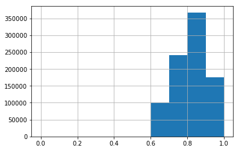

```python
df['AGE'].hist(bins=10)
```

#### Cross-tabulation of patients by READMISSION1

```python
result = df[['READMISSION1']].apply(pd.value_counts).fillna(0).T
result.index=['READMISSION1']
result.columns=['No Readmission', 'Readmission']
pd.options.display.float_format = '{:,.0f}'.format

# cross tabulated result
result
```

|  | No Readmission | Readmission |
| --- | --- | --- |
| READMISSION1 | 837667 | 47835 |

#### Bar plot of number of patient by READMISSION1

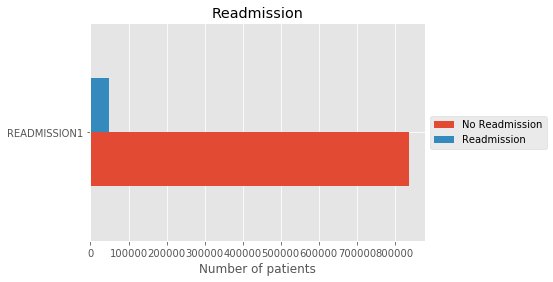

```python
import matplotlib
import matplotlib.pyplot as plt
matplotlib.style.use('ggplot')

# horizontal bar plot
plt=result.plot.barh(title="Readmission")
plt.set_xlabel("Number of patients")
plt.legend(loc='center left', bbox_to_anchor=(1, 0.5))
plt

# horizontal bar plot stacked
#result.plot.barh(title="Physical Function", stacked=True).legend(loc='center left', bbox_to_anchor=(1, 0.5))
```

# SKIP TO MACHINE LEARNING

#### Box plot showing distribution of patients by physical function

```python
# Boxplot
fig = matplotlib.pyplot.gcf()
fig.set_size_inches(12, 6)
fig.suptitle('Physical Function', fontsize=12)
plt = result.boxplot()
```

[output not shown]

```python
import numpy as np
import pandas as pd
import scipy.stats as stats

result_population = df[['CHOR','STAIR','W15','ERANDS']].apply(pd.value_counts).fillna(0)
df_observed = df.loc[df['READMISSIONS1']==1]
result_observed = df_observed[['CHOR','STAIR','W15','ERANDS']].apply(pd.value_counts).fillna(0)

# remove small values (Category 0)
result_population = result_population[1:]
result_observed = result_observed[1:]

# Get observed counts
print()
print("Chi statistic, p-values for 'STAIR','W15','ERANDS'")
print ( stats.chisquare(f_obs= result_observed,   # Array of observed counts
                f_exp= result_population) )  # Array of expected counts
```

[output not shown]

### Pain Intensity

NRS - 3. In the past 7 days, how would you rate your low-back pain on average?

#### Cross-tabulation of patients by pain intensity

```python
result = df[['NRS']].apply(pd.value_counts).fillna(0).T
#result.reindex_axis(sorted(result.columns), axis=1)
#result.sort_index(axis=1)
pd.options.display.float_format = '{:,.0f}'.format
result = result[[0,1,2,3,4,5,6,7,8,9,10]]
result
```

[output not shown]

#### Bar plot of number of patient by pain intensity

```python
plt = result.plot.barh(title="Pain Intensity")
plt.legend(loc='center left', bbox_to_anchor=(1, 0.5))
plt.set_xlabel("Number of patients")
#result.plot.barh(title="Pain Intensity", stacked=True).legend(loc='center left', bbox_to_anchor=(1, 0.5))
```

[output not shown]

#### Is the distriubution of pain intensity categories affected by opioid pain killers?

```python
import numpy as np
import pandas as pd
import scipy.stats as stats

df_observed = df.loc[df['OPI']==1]
result_population = df[['NRS']].apply(pd.value_counts).fillna(0)
result_observed = df_observed[['NRS']].apply(pd.value_counts).fillna(0)

# remove
result_population = result_population[1:]

print("Population (1='No pain' -> 10 'Worst imaginable pain')")
print( result_population.sort_index() )
print()
print("Observed with OPI=1")
print( result_observed.sort_index() )

# Get observed counts
print()
print("Chi statistic, p-values for 'NRS'")
print ( stats.chisquare(f_obs= result_observed,   # Array of observed counts
                f_exp= result_population) )  # Array of expected counts
```

[output not shown]

#### Comparitive analysis of duration, frequency, pain intensity, and raduculopathy

DUR - 1. How long has low-back pain been an ongoing problem for you?  
FREQ-2. How often has low-back pain been an ongoing problem for you over the past 6 months?  
NRS - 3. In the past 7 days, how would you rate your low-back pain on average?  
RAD - 4. Has back pain spread down your leg(s) during the past 2 weeks? (radiculopathy)

```python
import matplotlib
import matplotlib.pyplot as plt
matplotlib.style.use('ggplot')

'''
['ID', 'DUR', 'FREQ', 'NRS', 'RAD', 'PIDAY', 'PIWORK', 'PPISOC',
       'PICHOR', 'LBS', 'OPI', 'INJ', 'EXE', 'PSY', 'UNEMP', 'DIS', 'ABD',
       'JOI', 'HEA', 'FIB', 'CHOR', 'STAIR', 'W15', 'ERANDS', 'WORTHL',
       'HELPL', 'DEPRES', 'HOPEL', 'SLEEPQ', 'SREFR', 'SPROB', 'SONSET',
       'CAT.SAFE', 'CAT.NEVER', 'LIT', 'AS', 'ETOH', 'SAHELP', 'AGE', 'SEX',
       'EMP', 'EDU', 'HT', 'WT', 'RACE', 'PI', 'FUN', 'DEP', 'SLEEP']
'''
fig, ax = plt.subplots(2,2)
# plt.subplots_adjust(10,10)
fig.set_size_inches(6, 6)
# ax.set_title('How long has low-back pain been an ongoing problem for you?')
df[['DUR', 'ID']].groupby(['DUR']).count().plot.bar(ax=ax[0][0], stacked=False, color='r')
ax[0][0].set_title('DUR')
ax[0][0].legend_.remove()
ax[0][0].set_ylabel('N')
ax[0][0].set_xlabel('')

df[['FREQ', 'ID']].groupby(['FREQ']).count().plot.bar(ax=ax[0][1], stacked=False, color='g')
ax[0][1].set_title('FREQ')
ax[0][1].legend_.remove()
#ax[0][1].set_ylabel('N')
ax[0][1].set_xlabel('')

df[['NRS', 'ID']].groupby(['NRS']).count().plot.bar(ax=ax[1][0], stacked=False, color='b')
ax[1][0].set_title('NRS')
ax[1][0].legend_.remove()
ax[1][0].set_ylabel('N')
ax[1][0].set_xlabel('')

df[['RAD', 'ID']].groupby(['RAD']).count().plot.bar(ax=ax[1][1], stacked=False, color='k')
ax[1][1].set_title('RAD')
ax[1][1].legend_.remove()
# ax[1][1].set_ylabel('N')
ax[1][1].set_xlabel('')
```

[output not shown]

#### Cross tab of duration, frequency, and pain intensity

```python
df[['DUR','FREQ','NRS']].describe()
```

[output not shown]

#### Distribution for raduculopathy

```python
df[['RAD']].describe()
```

[output not shown]

### Machine learning methods for feature selection and predictive accuracy

Validate using 10-fold cross validation.

List the accuracy and the confusion matrix.

```python
df.head()
```

|  | CASEID | SEX | RACE_NEW | CPT | CPT.1 | WORKRVU | INOUT | TRANST | TRANST_From acute care hospital inpatient | TRANST_Not transferred (admitted from home) | ... | ASACLAS_1-No Disturb | ASACLAS_2-Mild Disturb | ASACLAS_3-Severe Disturb | ASACLAS_4-Life Threat | ASACLAS_5-Moribund | ASACLAS_None assigned | STILLINHOSP | SEPSHOCKPATOS | REOPERATION1 | READMISSION1 |
| --- | --- | --- | --- | --- | --- | --- | --- | --- | --- | --- | --- | --- | --- | --- | --- | --- | --- | --- | --- | --- | --- |
| 0 | 3873447 | 1 | 0 | 47562 | 47562 | 0 | 0 | Not transferred (admitted from home) | 0 | 1 | ... | 0 | 0 | 1 | 0 | 0 | 0 | 0 | 0 | 0 | 0 |
| 1 | 3873448 | 0 | 0 | 11043 | 11043 | 0 | 1 | Not transferred (admitted from home) | 0 | 1 | ... | 0 | 0 | 0 | 1 | 0 | 0 | 0 | 1 | 0 | 0 |
| 2 | 3873449 | 0 | 0 | 34201 | 34201 | 0 | 1 | Outside emergency department | 0 | 0 | ... | 0 | 0 | 1 | 0 | 0 | 0 | 0 | 0 | 0 | 0 |
| 3 | 3873450 | 0 | 0 | 50546 | 50546 | 0 | 1 | Not transferred (admitted from home) | 0 | 1 | ... | 0 | 1 | 0 | 0 | 0 | 0 | 0 | 0 | 0 | 0 |
| 4 | 3873470 | 0 | 0 | 45130 | 45130 | 0 | 1 | Not transferred (admitted from home) | 0 | 1 | ... | 0 | 0 | 1 | 0 | 0 | 0 | 0 | 0 | 0 | 0 |

5 rows × 88 columns

#### Logistic Regression

Binary Logistic Regression is a special type of regression where binary response variable is related to a set of explanatory variables, which can be discrete and/or continuous.

```python
from sklearn.model_selection import cross_val_score
from sklearn.model_selection import train_test_split
from sklearn.linear_model import LogisticRegression
from sklearn import svm
# X_train, X_test, y_train, y_test = train_test_split(iris.data, iris.target, test_size=0.4, random_state=0

features = ['SEX', 'RACE_NEW', 'CPT.1', 'WORKRVU', 'INOUT',
       'TRANST_From acute care hospital inpatient',
       'TRANST_Not transferred (admitted from home)',
       'TRANST_Nursing home - Chronic care - Intermediate care',
       'TRANST_Outside emergency department', 'TRANST_Transfer from other',
       'TRANST_Unknown', 'AGE', 'DISCHDEST_Expired',
       'DISCHDEST_Facility Which was Home', 'DISCHDEST_Home',
       'DISCHDEST_Rehab', 'DISCHDEST_Separate Acute Care',
       'DISCHDEST_Skilled Care, Not Home', 'DISCHDEST_Unknown',
       'DISCHDEST_Unskilled Facility Not Home',
       'ANESTHES_Epidural', 'ANESTHES_General', 'ANESTHES_Local',
       'ANESTHES_MAC/IV Sedation', 'ANESTHES_None', 'ANESTHES_Other',
       'ANESTHES_Regional', 'ANESTHES_Spinal', 'ANESTHES_Unknown',
       'SURGSPEC_Cardiac Surgery', 'SURGSPEC_General Surgery',
       'SURGSPEC_Gynecology', 'SURGSPEC_Interventional Radiologist',
       'SURGSPEC_Neurosurgery', 'SURGSPEC_Orthopedics',
       'SURGSPEC_Otolaryngology (ENT)', 'SURGSPEC_Plastics',
       'SURGSPEC_Thoracic', 'SURGSPEC_Urology', 'SURGSPEC_Vascular',
       'BMI', 'DIABETES_INSULIN', 'DIABETES_NO',
       'DIABETES_NON-INSULIN', 'SMOKE', 'DYSPNEA_AT REST',
       'DYSPNEA_MODERATE EXERTION', 'DYSPNEA_No',
       'FNSTATUS2_Independent', 'FNSTATUS2_Partially Dependent',
       'FNSTATUS2_Totally Dependent', 'FNSTATUS2_Unknown', 'VENTILAT',
       'ASCITES', 'HXCHF', 'HYPERMED', 'RENAFAIL', 'DIALYSIS', 'DISCANCR',
       'WNDINF', 'STEROID', 'WTLOSS', 'BLEEDIS', 'TRANSFUS', 'PRSEPIS',
       'EMERGNCY', 'ASACLAS_1-No Disturb', 'ASACLAS_2-Mild Disturb',
       'ASACLAS_3-Severe Disturb', 'ASACLAS_4-Life Threat',
       'ASACLAS_5-Moribund', 'ASACLAS_None assigned']

# Targets: 'STILLINHOSP','SEPSHOCKPATOS', 'REOPERATION1', 'READMISSION1'
target = ['READMISSION1']

labels = df[target]["READMISSION1"]

# fit a logistic regression model to the data
model = LogisticRegression()
model.fit(df[features], labels)
print(model)

# make predictions

expected = df[target]
predicted = model.predict(df[features])

# # summarize the fit of the model
# print(metrics.classification_report(expected, predicted))
# print(metrics.confusion_matrix(expected, predicted))

scores = cross_val_score(model, df[features], df[target]["READMISSION1"], cv=10)
print( "Cross validation scores using all features")
print(scores )

# The mean score and the 95% confidence interval of the score estimate are hence given by:
print("Mean accuracy using all features: %0.2f (+/- %0.2f)" % (scores.mean(), scores.std() * 2))
```

```
LogisticRegression(C=1.0, class_weight=None, dual=False, fit_intercept=True,
          intercept_scaling=1, max_iter=100, multi_class='ovr', n_jobs=1,
          penalty='l2', random_state=None, solver='liblinear', tol=0.0001,
          verbose=0, warm_start=False)
Cross validation scores using all features
[ 0.94597464  0.94597464  0.94597464  0.94597464  0.94597464  0.94598532
  0.94598532  0.94598471  0.94598471  0.94598471]
Mean accuracy using all features: 0.95 (+/- 0.00)
```

*Accuracy is ~0.95 for a Logistic Regression Model using all features to predict READMISSION1.*

#### Support Vector Machine

Discriminative classifier formally defined by a separating hyperplane. In other words, given labeled training data (supervised learning), the algorithm outputs an optimal hyperplane which categorizes new examples.

```python
from sklearn import datasets
from sklearn import metrics
from sklearn import svm

labels = df[target]['READMISSION1']

# fit a logistic regression model to the data
model = svm.SVC(kernel='linear', C=1)
model.fit(df[features], labels)
print(model)

# make predictions
expected = df[target]
predicted = model.predict(df[features])

# # summarize the fit of the model
# print(metrics.classification_report(expected, predicted))
# print(metrics.confusion_matrix(expected, predicted))

scores = cross_val_score(model, df[features], df[target]["READMISSION1"], cv=10)
print( "Cross validation scores using all features")
print(scores )

# The mean score and the 95% confidence interval of the score estimate are hence given by:
print("Mean accuracy using all features: %0.2f (+/- %0.2f)" % (scores.mean(), scores.std() * 2))
```

[output not shown]